# Motif & Feature Enrichment

# Load Libraries & ArchR object

```r
library(ArchR)
library(rhdf5)
library(reticulate)
library(tidyverse)
#library(caret)
h5disableFileLocking()

# load ArchR project
proj <- loadArchRProject(path = "Save_Vignette_object_3/")

# for R to find macs2 we will use a conda environment where the latest version
# of macs2 is installed
#conda_list()[[1]][2] %>% use_condaenv(required = TRUE)
```

# Motif and Feature Enrichment

We have identified robust peak sets and now we want to know which TFs bind to the peak region and thereby create an accessible region. Are the marker peaks enriched for binding sites of specific TFs? For example, a lineage-defining TF will often be enriched in cell-type specific peaks. We might also want to know if a cell type-specific peak is enriched for CHIP-seq peaks or other features.

## Motif Enrichment in Differential Peaks

We will first add the motif annotations to the ArchRProject. We create a binary matrix, where the presence or absence of a motif in a peak is indicated. Using the list of differential peaks more accessible in “Erythroid” than in “Progenitor” cells, we can define the peaks we want to test for motif enrichment. Using the `peakAnnoEnrichment()` function we test for enrichment.

A **hypergeometric test** is used to test the probability of observing the motif at the given frequency by chance, comparing with a background set of peaks matched for GC content.

```r
# add motif annotations
# this function requires the ChromVar package
proj <- addMotifAnnotations(ArchRProj = proj,
                            motifSet = "cisbp",
                            name = "Motif")

# get markers between erythroid and progenitor cells
markerTest <- getMarkerFeatures(
  ArchRProj = proj,
  useMatrix = "PeakMatrix",
  groupBy = "Clusters2",
  testMethod = "wilcoxon",
  bias = c("TSSEnrichment", "log10(nFrags)"),
  useGroups = "Erythroid",
  bgdGroups = "Progenitor"
)

# test for motif enrichment
motifsUp <- peakAnnoEnrichment(
  seMarker = markerTest,
  ArchRProj = proj
)

motifsUp
## class: SummarizedExperiment
## dim: 870 1
## metadata(0):
## assays(10): mlog10Padj mlog10p ... CompareFrequency feature
## rownames(870): TFAP2B_1 TFAP2D_2 ... TBX18_869 TBX22_870
## rowData names(0):
## colnames(1): Erythroid
## colData names(0):
```

For plotting the motifs we create a dataframe containing the motifs, p-values and the significance rank. In the dataframe we can see that the most motifs enriched in the accessbile peaks are GATA transcription factors which is a TF very important for erythroid differentiation.

```r
df <- data.frame(TF = rownames(motifsUp), mlog10Padj = assay(motifsUp)[,1])

df <- df %>% arrange(desc(mlog10Padj))
# create a sequenc of desired length for the rank of each TF motif
df$rank <- seq_len(nrow(df))
df %>% head %>% knitr::kable()
```

| TF | mlog10Padj | rank |
| --- | --- | --- |
| GATA2_388 | 512.8758 | 1 |
| GATA1_383 | 504.3724 | 2 |
| GATA3_384 | 427.0672 | 3 |
| GATA5_385 | 408.9895 | 4 |
| GATA4_386 | 291.6171 | 5 |
| GATA6_387 | 219.8980 | 6 |

In the plot below the TF motifs are sorted by rank and colored by significance of their enrichment.

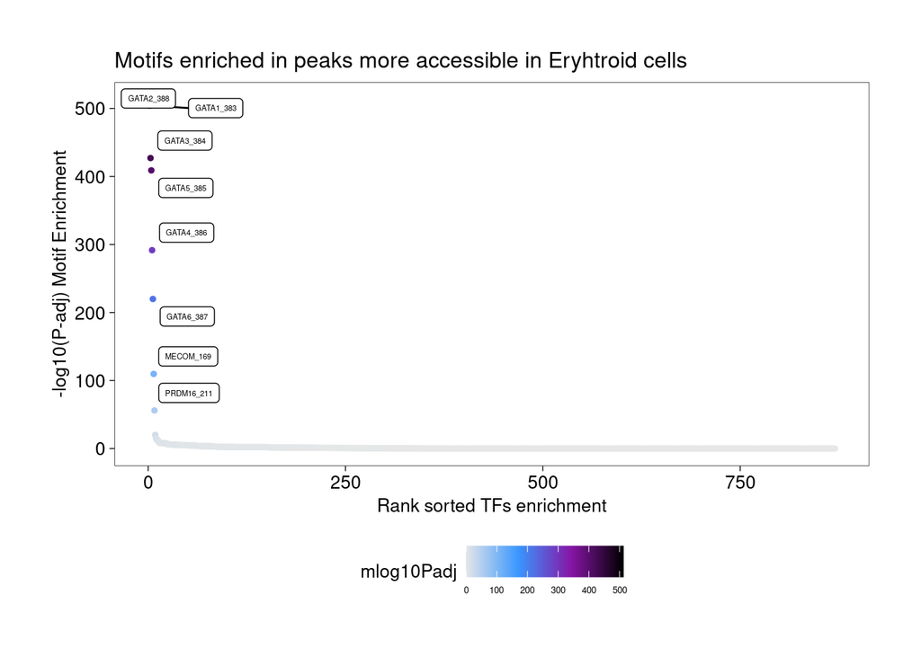

```r
ggUp <- ggplot(df, aes(rank, mlog10Padj, color = mlog10Padj)) +
  geom_point(size = 1) +
  ggrepel::geom_label_repel(
    data = df[rev(seq_len(30)), ], aes (x = rank, y = mlog10Padj, label = TF),
    size = 1.5, nudge_x = 2,
    color = "black",
    max.overlaps = 30
  ) +
  theme_ArchR() +
  ylab("-log10(P-adj) Motif Enrichment") +
  xlab("Rank sorted TFs enrichment") +
  scale_color_gradientn(colors = paletteContinuous(set = "comet")) +
  labs(title = "Motifs enriched in peaks more accessible in Eryhtroid cells")
ggUp
## Warning: ggrepel: 22 unlabeled data points (too many overlaps). Consider
## increasing max.overlaps
```

```r
motifsDo <- peakAnnoEnrichment(
    seMarker = markerTest,
    ArchRProj = proj,
    peakAnnotation = "Motif",
    cutOff = "FDR <= 0.1 & Log2FC <= -0.5"
  )

# create a dataframe for plotting
df <- data.frame(TF = rownames(motifsDo), mlog10Padj = assay(motifsDo)[,1])
df <- df %>% arrange(desc(mlog10Padj))
df$rank <- seq_len(nrow(df))
df %>% head %>% knitr::kable()
```

| TF | mlog10Padj | rank |
| --- | --- | --- |
| TCF12_56 | 77.08976 | 1 |
| ELF2_326 | 76.57926 | 2 |
| RUNX1_733 | 63.31046 | 3 |
| CBFB_801 | 58.27316 | 4 |
| RUNX2_732 | 55.19296 | 5 |
| ENSG00000250096_734 | 55.19296 | 6 |

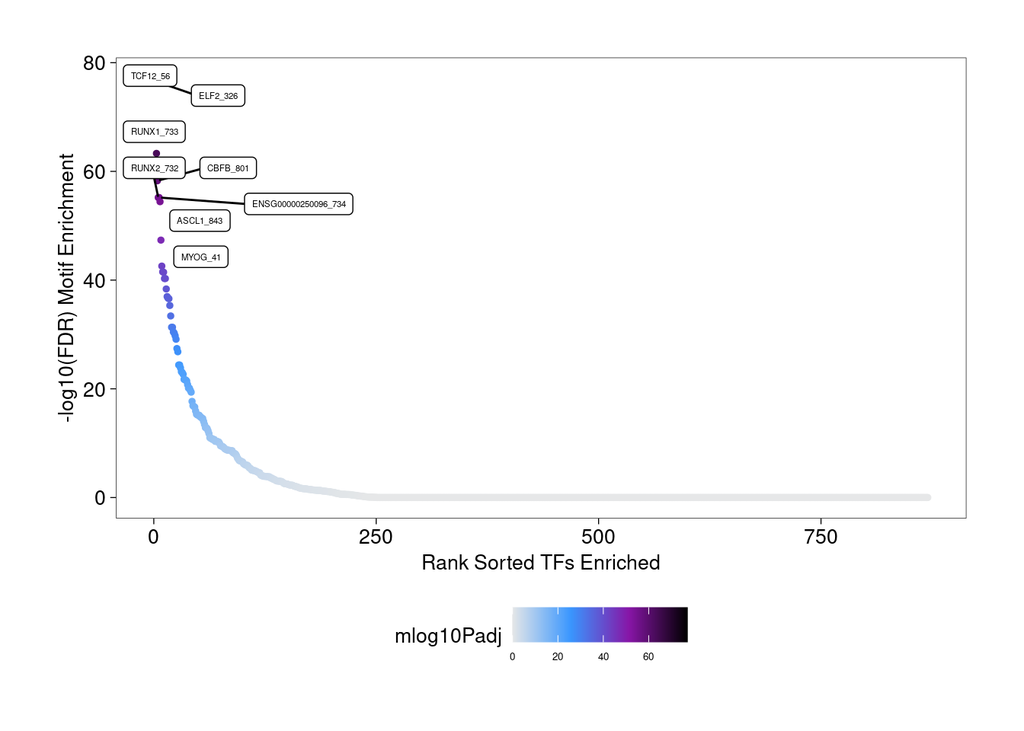

```r
ggDo <- ggplot(df, aes(rank, mlog10Padj, color = mlog10Padj)) +
  geom_point(size = 1) +
  ggrepel::geom_label_repel(
        data = df[rev(seq_len(30)), ], aes(x = rank, y = mlog10Padj, label = TF),
        size = 1.5,
        nudge_x = 2,
        color = "black"
  ) + theme_ArchR() +
  ylab("-log10(FDR) Motif Enrichment") +
  xlab("Rank Sorted TFs Enriched") +
  scale_color_gradientn(colors = paletteContinuous(set = "comet"))

ggDo
## Warning: ggrepel: 22 unlabeled data points (too many overlaps). Consider
## increasing max.overlaps
```

## Motif Enrichment in Marker Peaks

We can also perform motif enrichment on marker peaks.

```r
# get marker peaks
markersPeaks <- getMarkerFeatures(
    ArchRProj = proj,
    useMatrix = "PeakMatrix",
    groupBy = "Clusters2",
  bias = c("TSSEnrichment", "log10(nFrags)"),
  testMethod = "wilcoxon"
)

# get enriched motifs
enrichMotifs <- peakAnnoEnrichment(
  seMarker = markersPeaks, # summarized exeriment object
  ArchRProj = proj,
  peakAnnotation = "Motif", # peak annotation object used for the hypergeometric testing
  cutOff = "FDR <= 0.01 & Log2FC >= 0.5"
)

enrichMotifs
## class: SummarizedExperiment
## dim: 870 11
## metadata(0):
## assays(10): mlog10Padj mlog10p ... CompareFrequency feature
## rownames(870): TFAP2B_1 TFAP2D_2 ... TBX18_869 TBX22_870
## rowData names(0):
## colnames(11): B CD4.M ... PreB Progenitor
## colData names(0):
```

The motif enrichments across all cell groups can be plotted in a heatmap. We will limit the total number of motifs shown per cell type to seven.

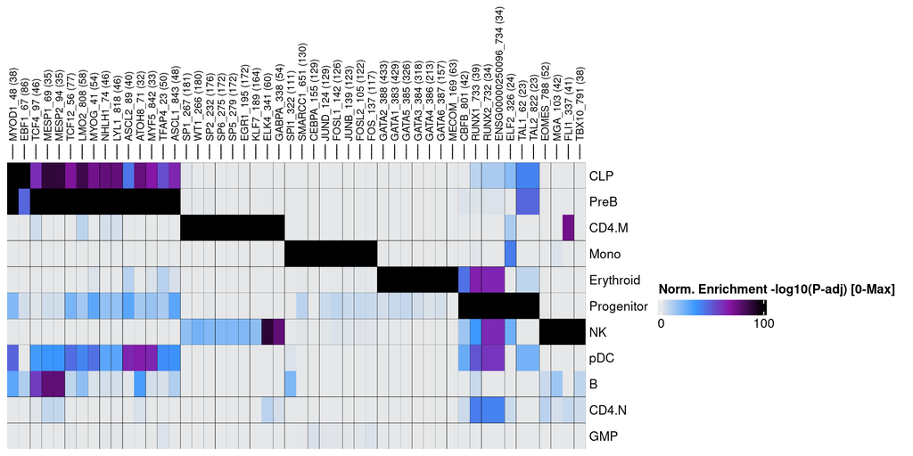

```r
heatmapEM <- plotEnrichHeatmap(enrichMotifs, n = 7, transpose = TRUE)
ComplexHeatmap::draw(heatmapEM)
```

# ChromVAR Deviations Enrichment with ArchR

TF motif enrichments can help us predict which regulatory factors are most active in a specific cell type. The enrichments do not take into account the insertion sequence bias of the Tn5 transposase and they are not calculated on a per-cell basis.

With ChromVAR we can predict TF enrichment per cell from sparse chromatin accessibility data. ChromVAR uses a lot of memory and runtime. In ArchR implements the same chromVAR analysis workflow by analyzing sample sub-matrices independently.

**Input**

- aligned sequencing reads
- chromatin accessibility peaks (aggregate across single cells)
- motif PWM (from cisBP)

**Outputs**

1. **deviations:** A bias corrected measurement on how much the per-cell accessibility of a given motif differs from the expected accessibility based on average of all cells
2. **z-score:** for each bias-corrected deviation across all cells. The deviation score is correlated with the per-cell read depth. A higher read depth means that you can have more confidence that a motif is actually enriched and that the deivation is not occuring by chance.

First, a group of Background peaks needs to be chose. ChromVAR samples peaks based on similarity in GC-content and number of fragments across all samples using the Mahalonobis distance. Afterwards, we are ready to compute per-cell deviations across all motif annotations.

Per-cell motif activity. Find differentially active motifs between cell types.

```r
# get background peaks
proj <- addBgdPeaks(proj)

# compute per-cell deviations across all motif annotations
# the deviation matrix will be motif x cell, containing information
# whether there is a gain or loss in activity of the motif
proj <- addDeviationsMatrix(
  ArchRProj = proj,
  peakAnnotation = "Motif",
  force = TRUE
)
## NULL

# the MotifMatrix is now saved in our ArchRProject
getAvailableMatrices(proj)
## [1] "GeneIntegrationMatrix" "GeneScoreMatrix"       "MotifMatrix"
## [4] "PeakMatrix"            "TileMatrix"
```

Below you can have a look at the deviations and a plot of deviations. The seqnames are not chromosomes, but instead this column contains `deviations` and `z`. The matrix stored as `MotifMatrix` is a sparse amtrix. For further analysis you might have to subset the matrix based on the seqnames.

```r
# have  a look at the dataframe
# the variability of the deviation will be ranked and the top variable anntoations
# will be labelled
getVarDeviations(proj, name = "MotifMatrix", plot = FALSE) %>%
  head %>% knitr::kable()
```

|  | seqnames | idx | name | combinedVars | combinedMeans | rank |
| --- | --- | --- | --- | --- | --- | --- |
| f388 | z | 388 | GATA2_388 | 12.12237 | -0.0362546 | 1 |
| f383 | z | 383 | GATA1_383 | 11.80604 | -0.0311180 | 2 |
| f336 | z | 336 | SPIB_336 | 11.35543 | -0.0827934 | 3 |
| f155 | z | 155 | CEBPA_155 | 11.05240 | -0.1776687 | 4 |
| f385 | z | 385 | GATA5_385 | 10.79069 | -0.0324980 | 5 |
| f651 | z | 651 | SMARCC1_651 | 10.27598 | -0.1299470 | 6 |

```r
# plot the deviations
plotVarDev <- getVarDeviations(proj, name = "MotifMatrix", plot = TRUE, n = 10)
```

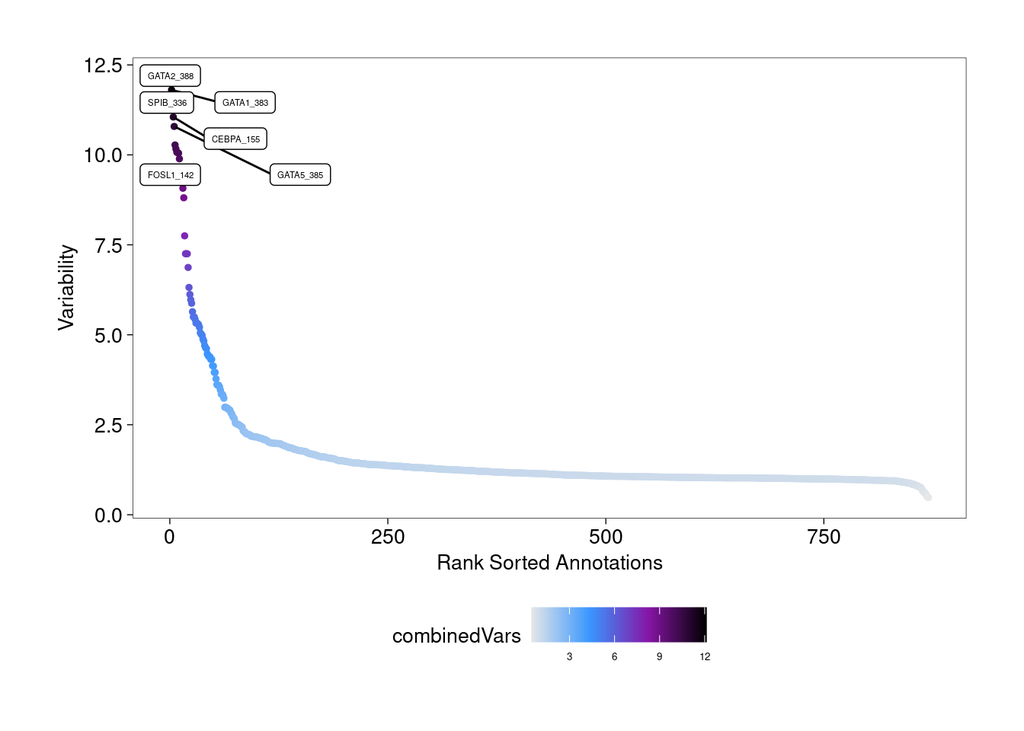

```r
plotVarDev
## Warning: ggrepel: 4 unlabeled data points (too many overlaps). Consider
## increasing max.overlaps
```

```r
# these are the features we want to extract
motifs <- c("GATA1", "CEBPA", "EBF1", "IRF4", "TBX21", "PAX5")

#save the deviation matrix for the marker motifs
markerMotifs <- getFeatures(ArchRProj = proj, useMatrix = "MotifMatrix",
                            select = paste(motifs, collapse = "|"))
markerMotifs
##  [1] "z:TBX21_780"          "z:PAX5_709"           "z:IRF4_632"
##  [4] "z:GATA1_383"          "z:CEBPA_155"          "z:EBF1_67"
##  [7] "z:SREBF1_22"          "deviations:TBX21_780" "deviations:PAX5_709"
## [10] "deviations:IRF4_632"  "deviations:GATA1_383" "deviations:CEBPA_155"
## [13] "deviations:EBF1_67"   "deviations:SREBF1_22"
```